# Avance

# Evolucion 2014-2019

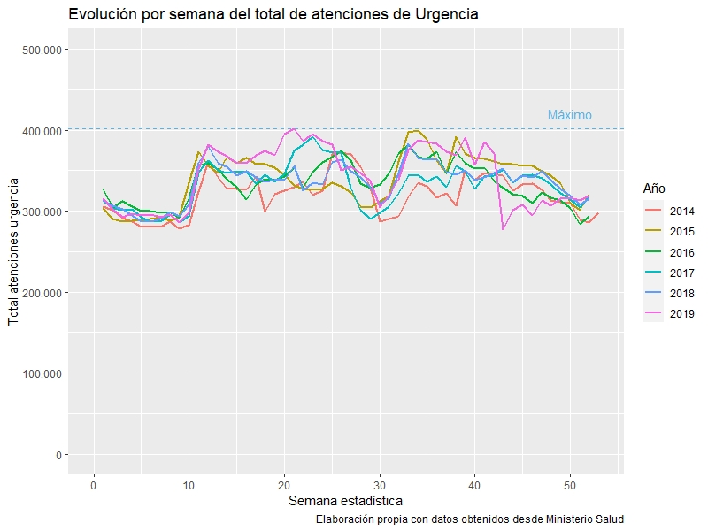

# Composición de las llegadas a urgencias 2014

Si tomamos un año sin grandes eventualidades como el año 2014, nos sería de gran utilidad conocer cuáles son los principales componentes de las entradas a urgencia. En la siguiente figura de manera de visualizar la proporción que toma cada elemento en las entradas a urgencia, realizaremos un gráfico de áreas apiladas.

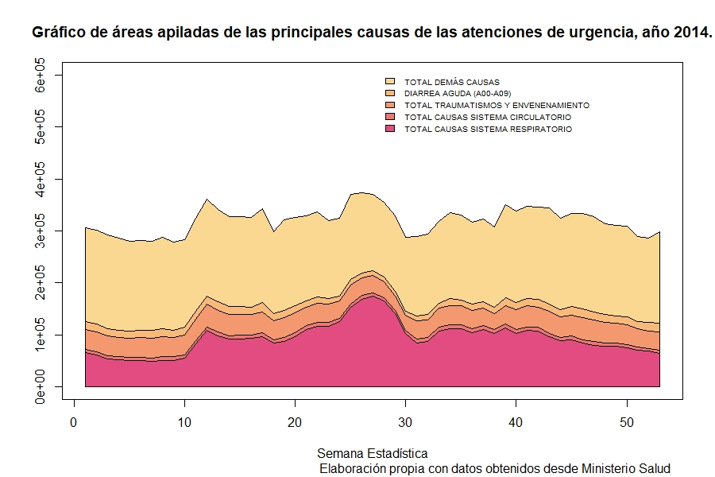

Es sencillo apreciar que las causas atribuídas al sistema respiratorio y causas generales son las que toman mayor proporción, por lo que sería útil entender cómo se comportan.

# Enfermades respiratorias

Como pudimos corroborar en el gráfico anterior una de las principales causas de las atenciones de urgencia en nuestro país son las enfermedades respiratorias,es decir, aquellas que afectan directamente los pulmones y derivados del aparato respiratorio. El Ministerio de Salud clasifica estas condiciones en Infecciones respiratorias altas, Influenza, Neumonía, Bronquitis, Crisis obstructiva y Causas generales. En la siguiente figura se muestran los casos totales de causas atribuídas al sistema respiratorio de todos los establecimientos de salud del país por cada semana del año 2014.

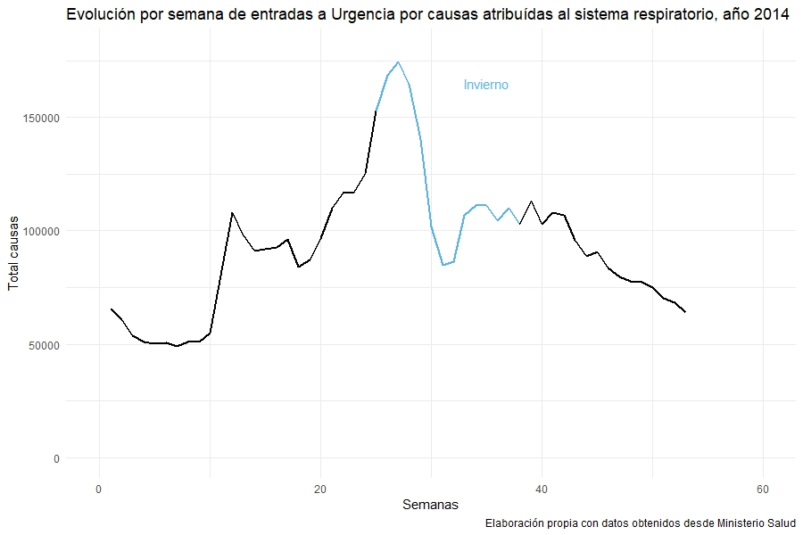

Es evidente que las causas totales tienen su valor máximo en las últimas semanas de otoño y las primeras semanas de invierno. Es por esto que a continuación nos enfocaremos en comprender cómo afectan estas llegadas de urgencia al sistema de salud y qué relación tienen con la proporción de camas disponibles.